# Итоговый проект

Группа 5

### Предобработка

Для построения рекомендательной системы нам необходимо было проверить гипотезу о наличии влияния съемочной группы (режиссёр + актёры) на рейтинг фильмов.

Проверять эту гипотезу мы решили следующим образом: объединением актеров и режиссеров в новую колонку “съемочная группа”, построив граф, где узлы — члены съемочной группы, связи — съемка в одном фильме. После этого были определены сообщества с помощью метода Louvain.

Затем мы рассчитали средний рейтинг фильмов по этим сообществам и провели ANOVA-тест, который показал, что различие в среднем рейтинге фильмов по сообществам является статистически значимым на любом принятом уровне значимости. **В дальнейшем это использовалось при построении content-based рекомендательной системы.**

```r
# Загрузка датасетов
library(tidyverse)
library(igraph)
library(recommenderlab)
library(readr)
library(tidyr)
load("~/shared/minor2_2023/data/project/metadata_g_5.RData")
```

```r
# Преобразование датасета: мы создадим новую колонку cast, которая будет состоять из следующих членов съемочной комады: режиссеров и актеров.
split_names = function(x) unlist(strsplit(x, ", "))

# создание колонки cast с актерами и режиссерами
metadata_filter = metadata %>%
  mutate(directedBy = map(directedBy, split_names),
         starring = map(starring, split_names),
         cast = map2(directedBy, starring, ~c(.x, .y))) %>%
  select(title, cast, avgRating, imdbId) %>%
  unnest_longer(cast) %>% distinct()

# Создание ветвей
edges_list = list()
titles = unique(metadata_filter$title)

for (title in titles) {
  cast_members = metadata_filter$cast[metadata_filter$title == title]
  if (length(cast_members) > 1) {
    combs = combn(cast_members, 2)
    edges_list = append(edges_list, list(combs))
  }
}
edges = unlist(edges_list)

# Создание графа
g = graph(edges = edges, directed = FALSE)

# Добавим атрибут рейтинг
V(g)$rating = sapply(V(g)$name, function(member) {
  mean(metadata_filter$avgRating[metadata_filter$cast == member])
})

# Составим сообщества
set.seed(1234)
communities = cluster_louvain(g)

# Рассчитаем размер сообществ
V(g)$community = communities$membership
community_sizes = data.frame(
  community = communities$membership,
  member = V(g)$name
) %>%
  group_by(community) %>%
  summarise(member_count = n())
```

#### Уберем ненаполненные сообщества (меньше 5 членов)

```r
large_communities = community_sizes %>% filter(member_count >= 5)
large_community_members = V(g)$name[V(g)$community %in% large_communities$community]

g_filtered = induced_subgraph(g, vids = V(g)$name %in% large_community_members)

set.seed(1234)
communities_filtered = cluster_louvain(g_filtered)

V(g_filtered)$community = communities_filtered$membership

# Рассчитаем количество сообществ
community_sizes_2 <- sizes(communities_filtered)
length(community_sizes_2) # Выявлено 33 сообщества
```

```
## [1] 33
```

```r
community_data = data.frame(
  community = as.factor(V(g_filtered)$community),
  rating = sapply(V(g_filtered)$name, function(member) {
    mean(metadata_filter$avgRating[metadata_filter$cast == member])
  })
)
```

Выявлено 33 сообщества.

#### Сделаем ANOVA-тест

В данном случае нулевая гипотеза следующая: “Съёмочная группа (режиссёр + актёры) не влияет на рейтинг фильмов”

```r
anova_result <- aov(rating ~ community, data = community_data)
anova(anova_result) # p-value < 2.2e-16
```

```
## Analysis of Variance Table
##
## Response: rating
##             Df  Sum Sq Mean Sq F value    Pr(>F)
## community   32  74.191  2.3185  24.612 < 2.2e-16 ***
## Residuals 2717 255.946  0.0942
## ---
## Signif. codes:  0 '***' 0.001 '**' 0.01 '*' 0.05 '.' 0.1 ' ' 1
```

Итог: p-value меньше любого уровня значимости => **нулевая гипотеза отвергается**: группы по съемочной команде статистически отличаются по оценке их фильмов. Получается, связь между съемочной группой и рейтингов фильма есть.

#### Построение столбчатой диаграммы

Показывает различия в средних рейтингах по сообществам

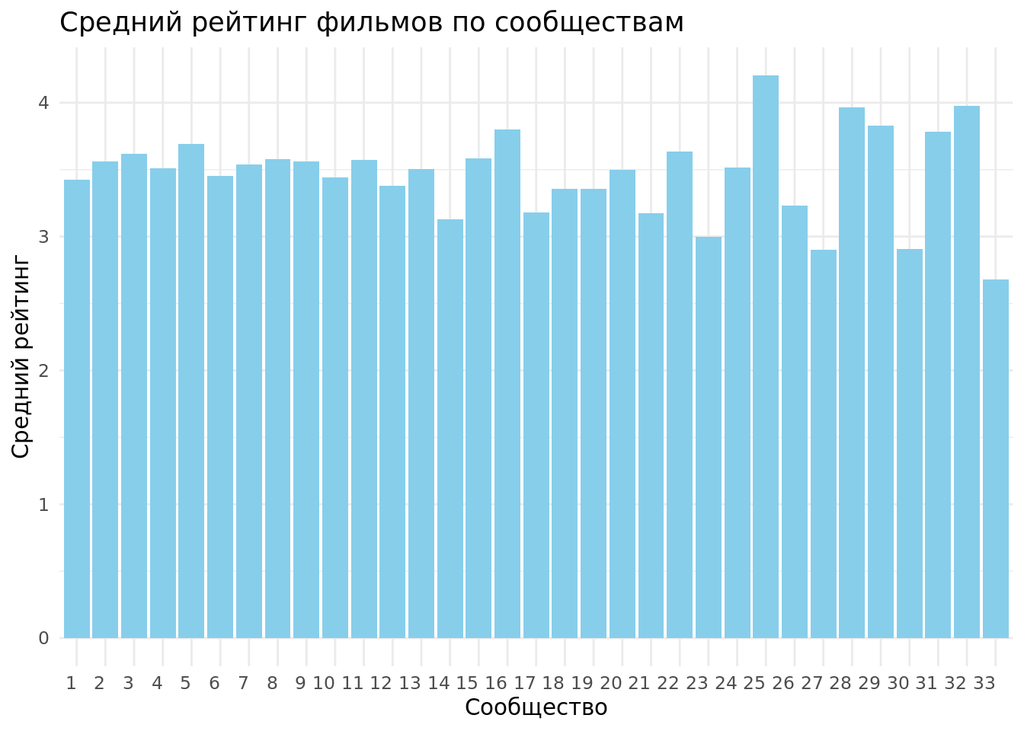

```r
mean_rating_for_bar = community_data %>% group_by(community) %>% summarize(mean_rating = mean(rating)) %>% ungroup()

ggplot(mean_rating_for_bar, aes(x = factor(community), y = mean_rating)) +
  geom_bar(stat = "identity", fill = "skyblue") +
  labs(title = "Средний рейтинг фильмов по сообществам",
       x = "Сообщество",
       y = "Средний рейтинг") +
  theme_minimal() +
  theme(axis.text.x = element_text(hjust = 1))
```

### Коллаборативная фильтрация

Используемый метод — **IBCF**.

Загружаем необходимые библиотеки и данные

```r
load("~/shared/minor2_2023/data/project/ratings_g_5.RData")
```

Добавляем собственные оценки фильмов для того, чтобы в дальнейшем использовать их для проверки адекватностии полученного предсказания исходя из личного опыта.

```r
ratings = as.data.frame(ratings)
ratings[nrow(ratings) + 1,] = c(4306, 1, 5.0)
ratings[nrow(ratings) + 1,] = c(1367, 1, 4.5)
ratings[nrow(ratings) + 1,] = c(33615, 1, 4.5)
ratings[nrow(ratings) + 1,] = c(50872, 1, 5.0)
ratings[nrow(ratings) + 1,] = c(122916, 1, 2.0)
ratings[nrow(ratings) + 1,] = c(3949, 1, 5.0)

# Внесение данных для ответа на пример №1
ratings[nrow(ratings) + 1,] = c(329, 2, 5.0)
ratings[nrow(ratings) + 1,] = c(3752, 2, 2.0)
ratings[nrow(ratings) + 1,] = c(3499, 2, 5.5)
ratings[nrow(ratings) + 1,] = c(46723, 2, 3.0)
ratings[nrow(ratings) + 1,] = c(2617, 2, 4.0)

# Внесение данных для ответа на пример №2
ratings[nrow(ratings) + 1,] = c(1884, 3, 0.5)
ratings[nrow(ratings) + 1,] = c(7090, 3, 0.5)
ratings[nrow(ratings) + 1,] = c(89745, 3, 0.5)
ratings[nrow(ratings) + 1,] = c(587, 3, 0.5)
ratings[nrow(ratings) + 1,] = c(72407, 3, 0.5)
ratings[nrow(ratings) + 1,] = c(86880, 3, 0.5)

# Внесение данных для ответа на пример №3
ratings[nrow(ratings) + 1,] = c(2329, 4, 0.5)
ratings[nrow(ratings) + 1,] = c(8949, 4, 0.5)
ratings[nrow(ratings) + 1,] = c(63113, 4, 0.5)
ratings[nrow(ratings) + 1,] = c(54272, 4, 0.5)
ratings[nrow(ratings) + 1,] = c(72011, 4, 0.5)
```

Теперь подготовим данные, убрав те, которые являются нерелевантными (если данных мало, основывать вывод на них бессмысленно). Так как если фильм редкий и его мало кто видел, то оценки для него могут быть сильно смещенными. Также если и пользователь оценил малое число фильмов, то ему сложно дать рекомендацию.

```r
counts = ratings %>% count(user_id)
counts %>% top_n(5, n) %>% arrange(-n)
```

```
##   user_id  n
## 1  928461 59
## 2   14662 54
## 3  341897 54
## 4  925231 52
## 5  589481 50
```

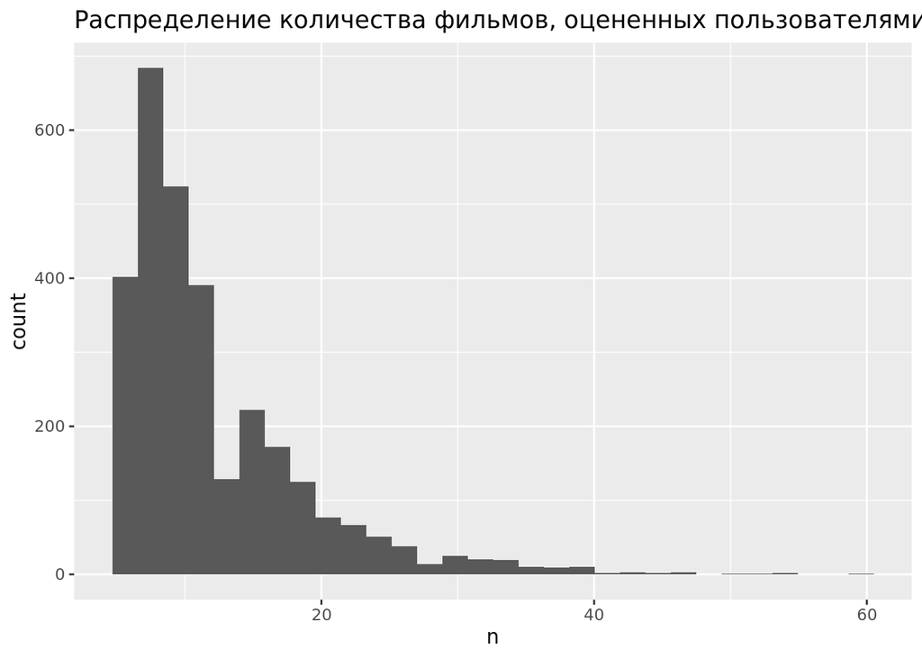

```r
ggplot(counts) + geom_histogram(aes(x = n)) + ggtitle("Распределение количества фильмов, оцененных пользователями")
```

```r
mean(counts$n)
```

```
## [1] 12.14847
```

```r
u <- unique(counts$n)
tab <- tabulate(match(counts$n, u))
u[tab == max(tab)]
```

```
## [1] 6
```

```r
counts_f = ratings %>% count(item_id)
counts_f %>% top_n(5, n) %>% arrange(-n)
```

```
##   item_id   n
## 1     356 330
## 2     296 310
## 3     318 304
## 4     593 294
## 5    1580 270
```

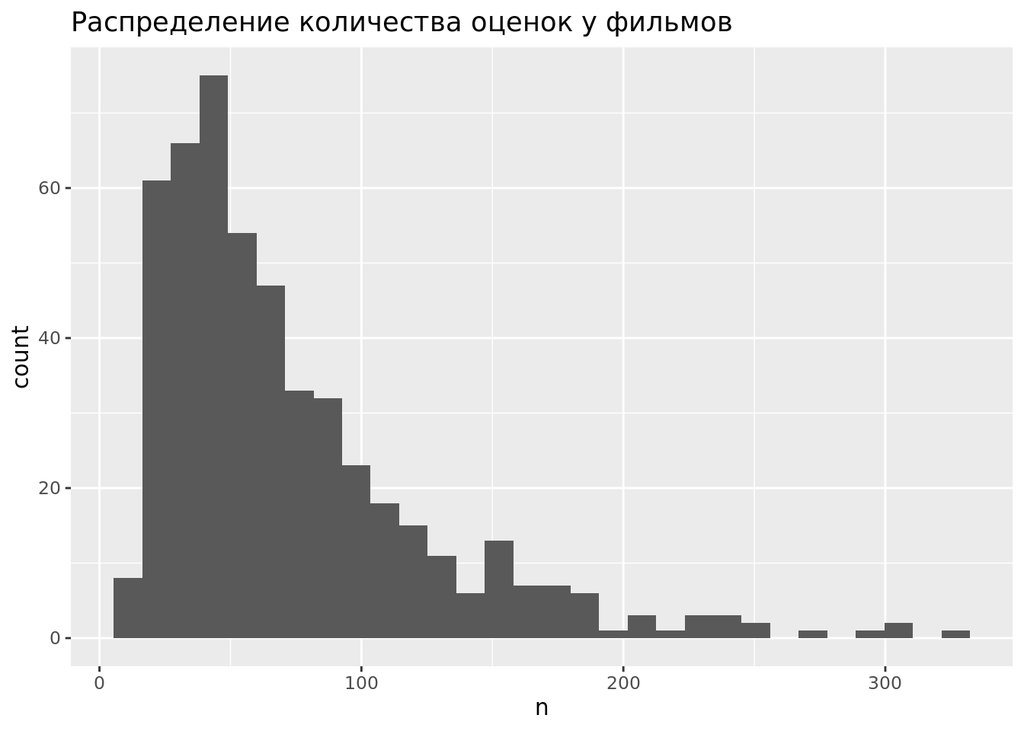

```r
ggplot(counts_f) + geom_histogram(aes(x = n)) + ggtitle("Распределение количества оценок у фильмов")
```

```r
rates = pivot_wider(ratings, names_from = item_id, values_from = rating)
```

Попробуем найти самые удачные данные по пользователям для построения модели. Для этого проверим 2 варианта: сильно урежем данные по пользователям (возьмем значение выше среднего арифметического по количеству оценок у пользователей) и немного урежем данные по пользователям (возьмем значение чуть выше минимального количества оценок у пользователей). Рассмотрим исходы следующих вариантов: 1) Нас интересуют пользователи, поставившие не менее 15 оценок. 2) Нас интересуют пользователи, поставившие не менее 8 оценок.

```r
userNames = rates$user_id
rates = select(rates, -user_id)
rates = as.matrix(rates)
rownames(rates) = userNames
r = as(rates, "realRatingMatrix")
ratings_movies_1 <- r[rowCounts(r) > 15]
ratings_movies_2 <- r[rowCounts(r) > 8]
```

Если у пользователей от 15 оценок:

```r
set.seed(100)
eval_sets1 <- evaluationScheme(data = ratings_movies_1,
                              method = "split",
                              train = 0.8, # доля обучающей выборки
                              given = 15, # сколько оценок используется для  предсказания
                              goodRating = 4) # если предсказанная оценка < 4, то фильм не рекомендуем
```

```r
recc_model1 <-
  Recommender(data = getData(eval_sets1, "train"), method = "IBCF")

recc_predicted1 <-
  predict(
    object = recc_model1,
    newdata = getData(eval_sets1, "known"),
    n = 5,
    type = "ratings"
  )
```

Вычисляем таблицу ошибок, усредненную на всех пользователей.

```r
eval_accuracy1 <- calcPredictionAccuracy(
      x = recc_predicted1,# predicted values
      data = getData(eval_sets1, "unknown"),
      byUser = F) # not averaging for each user

eval_accuracy1
```

```
##      RMSE       MSE       MAE
## 1.2783770 1.6342477 0.9478752
```

Теперь проверим с пользователями, у которых от 8 оценок:

```r
set.seed(100)
eval_sets2 <- evaluationScheme(data = ratings_movies_2,
                              method = "split",
                              train = 0.8, # доля обучающей выборки
                              given = 5, # сколько оценок используется для  предсказания
                              goodRating = 4) # если предсказанная оценка < 4, то фильм не рекомендуем
```

```r
recc_model2 <-
  Recommender(data = getData(eval_sets2, "train"), method = "IBCF")

recc_predicted2 <-
  predict(
    object = recc_model2,
    newdata = getData(eval_sets2, "known"),
    n = 8,
    type = "ratings"
  )
```

```r
eval_accuracy2 <- calcPredictionAccuracy(
      x = recc_predicted2,# predicted values
      data = getData(eval_sets2, "unknown"),
      byUser = F) # not averaging for each user

eval_accuracy2
```

```
##      RMSE       MSE       MAE
## 1.1870910 1.4091850 0.8734997
```

Мы можем сравнить полученные модели. Как видно из результатов, наиболее низкие показатели ошибки по всем трем параметрам в сравнении с другими показывает вторая модель, при которой мы оставляли лишь пользователей, оценивших больше 8 фильмов.

```r
eval_accuracy1
```

```
##      RMSE       MSE       MAE
## 1.2783770 1.6342477 0.9478752
```

```r
eval_accuracy2
```

```
##      RMSE       MSE       MAE
## 1.1870910 1.4091850 0.8734997
```

#### Функция

Создадим функцию, которая дает рекомендации пользователю. Входные данные: id пользователя и желаемое количество рекомендаций (n). Выходные параметры: название n фильмов, рекомендованных пользователю.

```r
get_rec <- function(id, n) {
  amount_of_films = ratings %>% filter(user_id == as.integer(id))
  if (nrow(amount_of_films)==0) {
    recommend = "Пожалуйста, оцените несколько фильмов, чтобы мы могли вам что-то порекомендовать."
  }
  else {
    recc_predicted <- predict(object = recc_model2, newdata = r, n = n)
          names(recc_predicted@items) = rownames(r)

          recc_user_1 <- recc_predicted@items[[id]]

          movies_user_1 <- recc_predicted@itemLabels[recc_user_1]
          names_movies_user_1 <- metadata$title[match(movies_user_1, metadata$item_id)]
          recommend = names_movies_user_1
  }
  print(recommend)
}
```

**Оценивание рекомендации:** работоспособность системы была проверена на основе формальных характеристик, что было показано выше. Кроме того, была проведена оценка выдаваемых системой результатов на адекватность: мы ознакомились с жанрами и кратким сюжетом выданных фильмов и сравнили их с теми, которые были оценены пользователем ранее, затем сделали выводы, насколько их характеристики коррелируются между собой.

Проверим на рандомном пользователе с id “4045”. Он оценивал фильмы, относящиеся к таким жанрам, как драма, фантастика, боевик (например, Форест Гамп, Я - легенда, «V» значит Вендетта, Кловерфилд, Эрин Брокович и пр.). Причем более высокие оценки (4.0-4.5) он ставит драматическим фильмам. Рекомендация ему выдала фильмы, которые относятся к жанрам: фантастика, боевик, триллер. Как кажется, эта рекомендация вполне адекватна.

```r
get_rec("4045", 3)
```

```
## [1] "Star Trek: Generations (1994)" "Three Musketeers, The (1993)"
## [3] "Misery (1990)"
```

Посмотрим результаты для себя – id “1”. Были оценены разнообразные фильмы, но по преимуществу это были комедийные и фэнтезийные фильмы (мультфильмы), например, Шрек, Рататуй, Мадагаскар. Кроме того, был добавлен Тор и Реквием по мечте – чтобы добавить больше фэнтези и драмы. В итоге рекомендация выдала больше фильмов, относящихся к комедии и фэнтези. В то же время Вавилон (фильм, 2006) - это драма, и он больше соотносится с Реквиемом по мечте. Думается, что это также подтверждает, что полученная рекомендация адекватна.

```r
get_rec("1", 5)
```

```
## [1] "Hudsucker Proxy, The (1994)" "Mummy, The (1999)"
## [3] "Me, Myself & Irene (2000)"   "Babel (2006)"
## [5] "Rocketeer, The (1991)"
```

### Content-based рекомендация

Загрузка необходимых библиотек и данных:

```r
data = metadata %>% dplyr::select(title, item_id, directedBy, starring, avgRating)

data[["avgRating"]] = data[["avgRating"]] / max(data$avgRating) # нормализуем рейтинг
data = subset(data, select = - c(avgRating))

library(qdapTools)
data = cbind(data, mtabulate(strsplit(data$directedBy, ", "))) # one hot режиссеров
data = cbind(data, mtabulate(strsplit(data$starring, ", "))) # one hot актеров
data = subset(data, select = - c(directedBy, starring))
```

Нормализуем вектора написанной функцией normalize_rows, затем сторим матрицу схожести и датасет из 5 фильмов с самым высоким рейтингом.

```r
normalize_rows = function(df) {
  df_norm = apply(df, 1, function(row) {
    row / sqrt(sum(row^2))
  })
  df_norm = data.frame(t(df_norm))
  colnames(df_norm) = colnames(df)
  return(df_norm)
}

rownames = data$item_id
data = subset(data, select = - c(item_id, title))
rownames(data) = rownames
data = normalize_rows(data)
sim = lsa::cosine(t(as.matrix(data)))
diag(sim) = 0

best = head(metadata[order(-metadata$avgRating),], n = 5) %>% select(title, avgRating)
```

#### Функция

Функция принимает на вход id пользователя, для каждого фильма, которому он поставил оценку 5 (если таких нет, то 4) функция находит 5 фильмов с самым большим косинусным сходством (с похожим актерским составом, режиссерами), объединяет рекомендации и возвращает топ-5 фильмов по рейтингу. Если пользователь не ставил оценки 4 или 5, то функция возвращает топ-5 фильмов с самым высоким рейтингом в датасете.

```r
getFilms = function(userId){
  if (nrow(ratings %>% filter(user_id == userId & rating == 5)) != 0) {
    user = ratings %>% filter(user_id == userId & rating == 5)
  } else if (nrow(ratings %>% filter(user_id == userId & rating == 4)) != 0) {
    user = ratings %>% filter(user_id == userId & rating == 4)
  } else {return(best)}
  find_and_combine = function(item_id) {
    mostSimilar = head(sort(sim[,as.character(item_id)], decreasing = T), n = 5)
    mostSimilar = data.frame(similar = mostSimilar)
    mostSimilar$item_id = as.numeric(rownames(mostSimilar))
    result = mostSimilar %>% left_join(metadata) %>% select(title, similar, directedBy, starring, avgRating) %>% arrange(-similar)
    return(result)
  }
  combined_results = lapply(user$item_id, find_and_combine)
  final_result = do.call(rbind, combined_results)
  return(head(final_result[order(-final_result$avgRating),], n = 5))
}
```

```r
getFilms(118278) #118278 473101
```

```
##                               title   similar        directedBy
## 4           Moonrise Kingdom (2012) 0.1230915      Wes Anderson
## 1          Kill Bill: Vol. 2 (2004) 0.2132007 Quentin Tarantino
## 2 Die Hard: With a Vengeance (1995) 0.1611646    John McTiernan
## 5              Planet Terror (2007) 0.1005038  Robert Rodriguez
## 3                 Armageddon (1998) 0.1285649       Michael Bay
##                                                                                                                                                                                                                                                 starring
## 4                                                                                 Bruce Willis, Edward Norton, Bill Murray, Kara Hayward, Frances McDormand, Tilda Swinton, Jason Schwartzman, Jared Gilman, Harvey Keitel, Bob Balaban, Charlie Kilgore
## 1                                                                                                                                  Uma Thurman, David Carradine, Michael Madsen, Daryl Hannah, Lucy Liu, Vivica A. Fox, Samuel L. Jackson, Michael Parks
## 2                                                                                                                                                            Bruce Willis, Jeremy Irons, Samuel L. Jackson, Nicholas Wyman, Larry Bryggman, Colleen Camp
## 5 Rose McGowan, Freddy Rodriguez, Josh Brolin, Marley Shelton, Jeff Fahey, Michael Biehn, Bruce Willis, Naveen Andrews, Julio Oscar Mechoso, Stacy Ferguson, Nicky Katt, Tom Savini, Quentin Tarantino, Danny Trejo, Cheech Marin, Zoe Bell, Ava Santana
## 3                                                                                             Ben Affleck, Billy Bob Thornton, Bruce Willis, Liv Tyler, Steve Buscemi, Will Patton, William Fichtner, Owen Wilson, Michael Clarke Duncan, Peter Stormare
##   avgRating
## 4   3.96894
## 1   3.82295
## 2   3.51406
## 5   3.51097
## 3   3.00808
```

**Оценивание рекомендации:** данная рекомендательная система оценивалась аналогично предыдущей, то есть на основе формальных характеристик, а также была проведена оценка выдаваемых системой результатов на адекватность.

### Примеры

##### Примеры collaborative filtering

В случае, если у пользователя не будет оценено ни одного фильма, ему выводится сообщение о том, что ему необходимо оценить несколько фильмов, чтобы у нас была возможность дать ему рекомендацию.

```r
get_rec("2", 2)
```

```
## [1] "Shrek (2001)"                     "Shawshank Redemption, The (1994)"
```

Как видим, в рекомендациях отражаются и приключенский жанр, и комедия, связанный с данными пользователем оценками, также имеется драматический фильм, соответсвующий высоким оценкам фильма такого же жанра

**Пример 2:** “Любопытно, что бы порекомендовалось пользователю, который поставил всем своим фильмам минимальные оценки?”

*Ответ:* Для ответа на этот вопрос мы предварительно добавили в датасет нового пользователя и присвоили ему id[3] в соответствии с данными характеристиками. Минимальная оценка = 0.5

Так как в вопросе не было указано, к какому жанру должны относиться фильмы, выбраны были рандомные, но всем присвоена низкая оценка.

```r
get_rec("3", 5)
```

```
## [1] "Kindergarten Cop (1990)"     "Rocketeer, The (1991)"
## [3] "Ed Wood (1994)"              "My Own Private Idaho (1991)"
## [5] "Event Horizon (1997)"
```

Преобладают жанры: драма, боевик. Если обратиться к фильмам, которые были добавлены для этого примера и которым были присвоены низкие оценки, станет ясно, что они действительно получились рандомными -- все они мало схожи по жанрам (Приведение, Сумерки, Пираты Карибского моря, Мстители, Герой (2002), Страх и ненависть в Лас-Вегасе). Полученные рекомендации при этом не выдают пользователю фильмы, похожие на непонравившиеся ему ранее -- то есть в выходных данных мы не находим фильмов с такими жанрами, как романтика, фэнтези, исторический нарратив, психоделика.

**Пример 3:** “Если были предложены фильмы основной жанр которых к примеру драма, и я поставил им всем низкие баллы, то какие фильмы мне предложит система?”

Для ответа на этот вопрос мы предварительно добавили в датасет нового пользователя и присвоили ему id[4]. Все фильмы с тэгом драма мы внесли ему и дали им минимальную оценку = 0.5

```r
get_rec("4", 5)
```

```
## [1] "Requiem for a Dream (2000)"         "Serenity (2005)"
## [3] "Back to the Future Part III (1990)" "Mrs. Doubtfire (1993)"
## [5] "Natural Born Killers (1994)"
```

Полученная рекомендация практически не выдает фильмы, относящиеся к жанру драма, за исключением фильма “Реквием по мечте”. Остальные относятся к жанрам: научная-фантастика, комедия, боевик, приключения.

##### Примеры content-based

**Пример 1:**

В рекомендательной системе content-based мы обговаривали такую ситуацию, когда пользователь ставил довольно низкие оценки на все фильмы (максимальная оценка меньше 4). Также по поводу этого было много вопросов в peer review. Мы решили, что в такой ситуации будем просто рекомендовать топ-5 фильмов, проверим это на примере пользователей с id 72774 и 68109. Вот их оценки:

```r
ratings %>% filter(user_id == '72774')
```

```
##   item_id user_id rating
## 1   53322   72774    3.0
## 2    1917   72774    3.0
## 3    8376   72774    1.0
## 4    7458   72774    3.5
## 5    7153   72774    3.0
## 6     150   72774    3.5
## 7   37733   72774    2.5
## 8    6711   72774    3.0
## 9    5956   72774    3.0
```

```r
ratings %>% filter(user_id == '68109')
```

```
##   item_id user_id rating
## 1    6157   68109    0.5
## 2     356   68109    3.5
## 3    4306   68109    2.0
## 4  111362   68109    3.5
## 5  122906   68109    3.5
## 6     296   68109    3.0
## 7    1591   68109    0.5
## 8   92420   68109    2.0
## 9   81932   68109    2.0
```

Как мы видим, они действительно не ставили оценок 4 и выше. Смотрим, что им порекомендует система:

```r
getFilms(72774)
```

```
##                                                    title avgRating
## 78                      Shawshank Redemption, The (1994)   4.41985
## 587 Spirited Away (Sen to Chihiro no kamikakushi) (2001)   4.22472
## 772  Lives of Others, The (Das leben der Anderen) (2006)   4.20356
## 206                                    Goodfellas (1990)   4.18818
## 71                                   Pulp Fiction (1994)   4.18760
```

```r
getFilms(68109)
```

```
##                                                    title avgRating
## 78                      Shawshank Redemption, The (1994)   4.41985
## 587 Spirited Away (Sen to Chihiro no kamikakushi) (2001)   4.22472
## 772  Lives of Others, The (Das leben der Anderen) (2006)   4.20356
## 206                                    Goodfellas (1990)   4.18818
## 71                                   Pulp Fiction (1994)   4.18760
```

Как мы видим, система работает правильно, и рекомендует верхушку из топа фильмов по рейтингу.

**Пример 2:** Также довольно много вопросов из peer review звучали примерно так: Мне нравятся фильмы с таким-то актером, будет ли система выводить другие фильмы с ним или что-то похожее? Проверим это на примере с Робертом де Ниро (так как он был в одном из вопросов). Для примера будем использовать пользователя с user id 527104, который поставил фильму Goodfellas (item_id = 1213) с де Ниро в главной роли оценку 5:

```r
ratings %>% filter(user_id == '527104')
```

```
##    item_id user_id rating
## 1     1213  527104    5.0
## 2   118696  527104    4.0
## 3     2108  527104    4.0
## 4     6947  527104    3.5
## 5       17  527104    5.0
## 6     1641  527104    4.0
## 7        2  527104    0.5
## 8    50872  527104    4.5
## 9     1882  527104    3.5
## 10  106782  527104    4.5
## 11   44555  527104    4.5
## 12    1680  527104    4.0
## 13    4816  527104    4.0
## 14     420  527104    3.0
```

[output cut: 26 more lines]

```r
getFilms(527104)
```

```
##                               title   similar
## 14 Silence of the Lambs, The (1991) 0.1443376
## 7    Remains of the Day, The (1993) 0.2000000
## 17            Monsters, Inc. (2001) 0.0000000
## 1              Bronx Tale, A (1993) 0.2165064
## 10     Stranger than Fiction (2006) 0.1825742
##                                   directedBy
## 14                            Jonathan Demme
## 7                                James Ivory
## 17 Pete Docter, David Silverman, Lee Unkrich
## 1                             Robert De Niro
## 10                              Marc Forster
##                                                                                                          starring
## 14                                          Jodie Foster, Anthony Hopkins, Scott Glenn, Anthony Heald, Ted Levine
## 7                                                    Anthony Hopkins, Emma Thompson, James Fox, Christopher Reeve
## 17        Steve Buscemi, James Coburn, Billy Crystal, John Goodman, Mary Gibbs, Jennifer Tilly, John Ratzenberger
## 1  Robert De Niro, Chazz Palminteri, Lillo Brancato, Francis Capra, Kathrine Narducci, Joe Pesci, Joe D'Onofrio,
## 10                                  Will Ferrell, Emma Thompson, Dustin Hoffman, Queen Latifah, Maggie Gyllenhaal
##    avgRating
## 14   4.15014
## 7    3.89243
## 17   3.84357
## 1    3.81965
## 10   3.78588
```

Как мы видим, наиболее похожий фильм, который выдает система - это Bronx Tale c де Ниро в главной роли. К тому же, этот фильм еще и в одном жанре со “Славными парнями”. Кажется, что система в данном случае сработала очень хорошо.

**Пример 3:** В данном случае мне кажется что было бы релевантно проверить связки актеров и режиссеров, которые много работали вместе и посмотреть будет ли система выдавать именно их например Мартин Скорсезе и Роберт Де Ниро (примечательно, что в датасете нет ни одного их общего фильма))))) Или что фильм Скорцезе с дикаприо должен реоменоваться пользователи больше, чем фильм скорцезе без дикаприо или фильм дикапрео без скорцезе.

Немного странный вопрос. Если пользователю не нравились фильмы Скорсезе и ДиКаприо, то, очевидно, что система не будет их рекомендовать. Поэтому проверим, будет ли система выдавать фильмы с этим режиссером и актером, если пользователь высоко оценивал их другие работы. Проверим это на пользователе с id 664013, который поставил 5 баллов фильму Волк с Уолл-стрит:

```r
getFilms(664013)
```

```
##                                title    similar        directedBy
## 1               Departed, The (2006) 0.14907120   Martin Scorsese
## 9            Moonrise Kingdom (2012) 0.12309149      Wes Anderson
## 6           Kill Bill: Vol. 2 (2004) 0.21320072 Quentin Tarantino
## 5 What's Eating Gilbert Grape (1993) 0.09622504   Lasse Hallström
## 2                Aviator, The (2004) 0.13074409   Martin Scorsese
##                                                                                                                                                                      starring
## 1                                      Leonardo DiCaprio, Matt Damon, Jack Nicholson, Mark Wahlberg, Martin Sheen, Alec Baldwin, Vera Farmiga, Ray Winstone, Anthony Anderson
## 9      Bruce Willis, Edward Norton, Bill Murray, Kara Hayward, Frances McDormand, Tilda Swinton, Jason Schwartzman, Jared Gilman, Harvey Keitel, Bob Balaban, Charlie Kilgore
## 6                                                       Uma Thurman, David Carradine, Michael Madsen, Daryl Hannah, Lucy Liu, Vivica A. Fox, Samuel L. Jackson, Michael Parks
## 5                                                                                             Johnny Depp, Leonardo DiCaprio, Juliette Lewis, Mary Steenburgen, Darlene Cates
## 2 Leonardo DiCaprio, Cate Blanchett, Kate Beckinsale, Alec Baldwin, Alan Alda, John C. Reilly, Ian Holm, Gwen Stefani, Jude Law, Willem Dafoe, Frances Conroy, Kevin O'Rourke
##   avgRating
## 1   4.13101
## 9   3.96894
## 6   3.82295
## 5   3.74624
## 2   3.60517
```

Как мы видим, один из рекомендованных фильмов - это “Отступники” Мартина Скорсезе с ДиКаприо в ролях.

**Пример 4:** Что будет, если я укажу, что хочу узнать рекомендации фильмов по пользователю с id 561711.

Не менее странный вопрос, но окей. Посмотрим, что выдаст система:

```r
getFilms(561711)
```

```
##                                                    title avgRating
## 78                      Shawshank Redemption, The (1994)   4.41985
## 587 Spirited Away (Sen to Chihiro no kamikakushi) (2001)   4.22472
## 772  Lives of Others, The (Das leben der Anderen) (2006)   4.20356
## 206                                    Goodfellas (1990)   4.18818
## 71                                   Pulp Fiction (1994)   4.18760
```

Видимо, пользователя с таким айди нет в системе, и она рекомендует просто топ-5 фильмов.

**Пример 5:** Я, например, очень хочу посмотреть фильм с Генри Кавиллом, что я получу на выход, и какой будет рейтинг у рекомендованных фильмов?

Предположим, ты высоко оценивал фильмы с Генри Кавиллом. Проверим, выдаст ли система другие фильмы с ним. Проверим это на примере пользователя c id 847268, который поставил 5 фильму “Агенты А.Н.К.Л”:

```r
getFilms(847268)
```

```
##                                   title   similar
## 3                 Monsters, Inc. (2001) 0.0000000
## 4 Fear and Loathing in Las Vegas (1998) 0.0000000
## 1                Sherlock Holmes (2009) 0.2672612
## 7                 Conjuring, The (2013) 0.1543033
## 5                       Sideways (2004) 0.0000000
##                                  directedBy
## 3 Pete Docter, David Silverman, Lee Unkrich
## 4                             Terry Gilliam
## 1                               Guy Ritchie
## 7                                 James Wan
## 5                           Alexander Payne
##                                                                                                                                                                                                                                                                                                          …
## 3                                                                                                                                                                                                                                                                                                        …
## 4 Johnny Depp, Benicio Del Toro, Tobey Maguire, Ellen Barkin, Gary Busey, Christina Ricci, Mark Harmon, Cameron Diaz, Katherine Helmond, Michael Jeter, Penn Jillette, Craig Bierko, Lyle Lovett, Flea, Laraine Newman, Harry Dean Stanton, Tim Thomerson, Larry Cedar, Richard Riehle, Richard Portnow, …
## 1                                                                                                                                                                                                                                                                                                        …
## 7                                                                                                                                                                                                                                                                                                        …
## 5                                                                                                                                                                                                                                                                                                        …
##   avgRating
## 3   3.84357
## 4   3.75318
## 1   3.74482
## 7   3.67185
## 5   3.65083
```

Система не вывела другие фильмы с этим актером, так как в датасете был только один фильм с Генри Кавиллом. Зато среди рекомендованных фильмов есть Шерлок Холмс, который немного схож по жанру с понравившимся фильмом.

**Дополнительный сценарий:** Найдите 2х пользователей, которым нравятся фильмы Мартина Скорсезе и фильмы, снятые до 2000 года. Порекомендуйте им что-то с помощью контент-бейзд системы. Насколько схожи результаты? Почему?

Мы будем проверять этот сценарий на примере двух пользователей: id_671196 и id_27355. Первый пользователь поставил оценку 5 следующим фильмам Скорсезе: Gangs of New York (2002) и Goodfellas (1990). Из фильмов до 2000 года ему понравились: Office Space (1999), Candyman (1992). Второму пользователю также понравился фильм Goodfellas (1990) Мартина Скорсезе, а из фильмов, снятых до 2000 года он оценил на 5: Iron Giant, The (1999), Teenage Mutant Ninja Turtles (1990), Lethal Weapon 3 (1992).

Посмотрим, какие рекомендации система выдаст первому пользователю:

```r
getFilms(671196)
```

```
##                                                             title   similar
## 48                                           Departed, The (2006) 0.1174440
## 4                                                    Fargo (1996) 0.2519763
## 54                                                   Fargo (1996) 0.2357023
## 62 Léon: The Professional (a.k.a. The Professional) (Léon) (1994) 0.1543033
## 53                                  No Country for Old Men (2007) 0.2672612
##               directedBy
## 48       Martin Scorsese
## 4  Joel Coen, Ethan Coen
## 54 Joel Coen, Ethan Coen
## 62            Luc Besson
## 53 Ethan Coen, Joel Coen
##                                                                                                                                  starring
## 48 Leonardo DiCaprio, Matt Damon, Jack Nicholson, Mark Wahlberg, Martin Sheen, Alec Baldwin, Vera Farmiga, Ray Winstone, Anthony Anderson
## 4                       William H. Macy, Frances McDormand, Steve Buscemi, Peter Stormare, Harve Presnell, Patrice Chéreau, Julien Temple
## 54                      William H. Macy, Frances McDormand, Steve Buscemi, Peter Stormare, Harve Presnell, Patrice Chéreau, Julien Temple
## 62                                                                     Jean Reno, Gary Oldman, Natalie Portman, Danny Aiello, Peter Appel
## 53                                                          Tommy Lee Jones, Javier Bardem, Josh Brolin, Woody Harrelson, Kelly Macdonald
##    avgRating
## 48   4.13101
## 4    4.11384
## 54   4.11384
## 62   4.09789
## 53   4.04205
```

А теперь смотрим на рекомендацию второму пользователю:

```r
getFilms(27355)
```

```
##                                    title   similar
## 5                      Inside Man (2006) 0.1543033
## 18                 Monsters, Inc. (2001) 0.0000000
## 11                  Bronx Tale, A (1993) 0.2165064
## 8                     Primal Fear (1996) 0.1414214
## 19 Fear and Loathing in Las Vegas (1998) 0.0000000
##                                   directedBy
## 5                                  Spike Lee
## 18 Pete Docter, David Silverman, Lee Unkrich
## 11                            Robert De Niro
## 8                             Gregory Hoblit
## 19                             Terry Gilliam
##                                                                                                                                                                                                                                                                                                          …
## 5                                                                                                                                                                                                                                                                                                        …
## 18                                                                                                                                                                                                                                                                                                       …
## 11                                                                                                                                                                                                                                                                                                       …
## 8                                                                                                                                                                                                                                                                                                        …
## 19 Johnny Depp, Benicio Del Toro, Tobey Maguire, Ellen Barkin, Gary Busey, Christina Ricci, Mark Harmon, Cameron Diaz, Katherine Helmond, Michael Jeter, Penn Jillette, Craig Bierko, Lyle Lovett, Flea, Laraine Newman, Harry Dean Stanton, Tim Thomerson, Larry Cedar, Richard Riehle, Richard Portnow,…
##    avgRating
## 5    3.89685
## 18   3.84357
## 11   3.81965
## 8    3.75891
## 19   3.75318
```

Единственное сходство, которое можно заметить в рекомендованных фильмах - это то, что большинство из них для обоих пользователей были сняты до 2000г. В целом фильмы рекомендуются довольно разные, но это может быть связано с тем, что оба пользователя были щедрыми на оценки: Первый пользователь поставил 5 всем фильмам, которые оценивал, а второй поставил одну оценку 2 и все остальные 5. Из-за этого системе пришлось выбирать из слишком большого списка.

### Выводы

Результаты сетевого анализа (доказанное с помощью статистического теста наличие связи между съёмочной группой и рейтингом фильма) легли в основу построения content-based рекомендательной системы, которая была нацелена на рекомендацию фильмов с «любимыми» режиссёрами и актёрами пользователю.

Рекомендательная система, построенная с помощью метода коллаборативной фильтрации, рекомендовала пользователям n-количество фильмов в зависимости от их схожести.

Обе рекомендательные системы работают корректно. Это было проверено при помощи формальной оценки, а также теста на адекватность.